# Рисунки для статьи

**Внимание!** При расчетах я использовал те файлы, которые прислала Мария! То есть в качестве датафреймов df_final и df_final2 я использовал не результаты вычислений по коду, а то, что прислали. Как я понял там находятся какие-то результаты ручного персчета.

## Динамика паразитемии

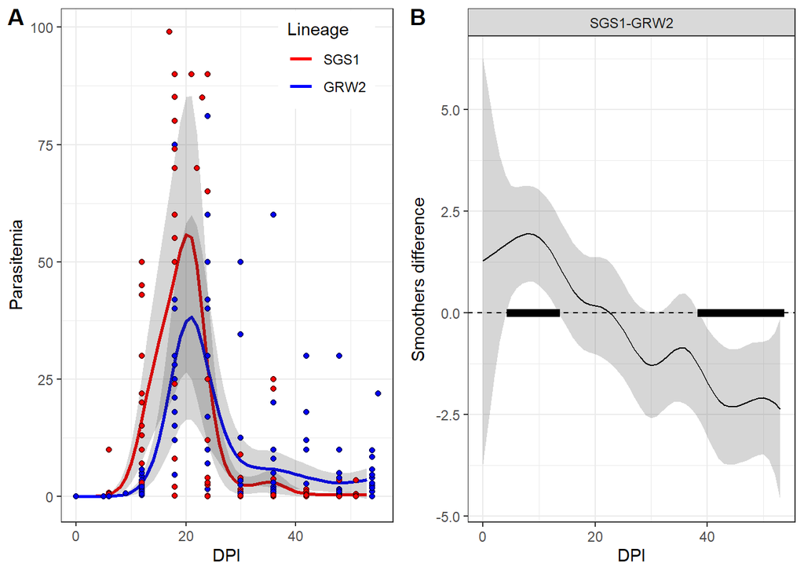

Figure +. Parasitemia at different days after inoculation (DPI) in two Plasmodium species. Panel A represents the observed number of merozoites (dots) and predicted GAM (lines, gray areas around the lines represent 95% CI). Panel B represents the difference between smoothers. Time periods when the difference between smoothers is significantly different from zero are marked by black rectangles.

## Динамика RMR на фоне развития заболевания

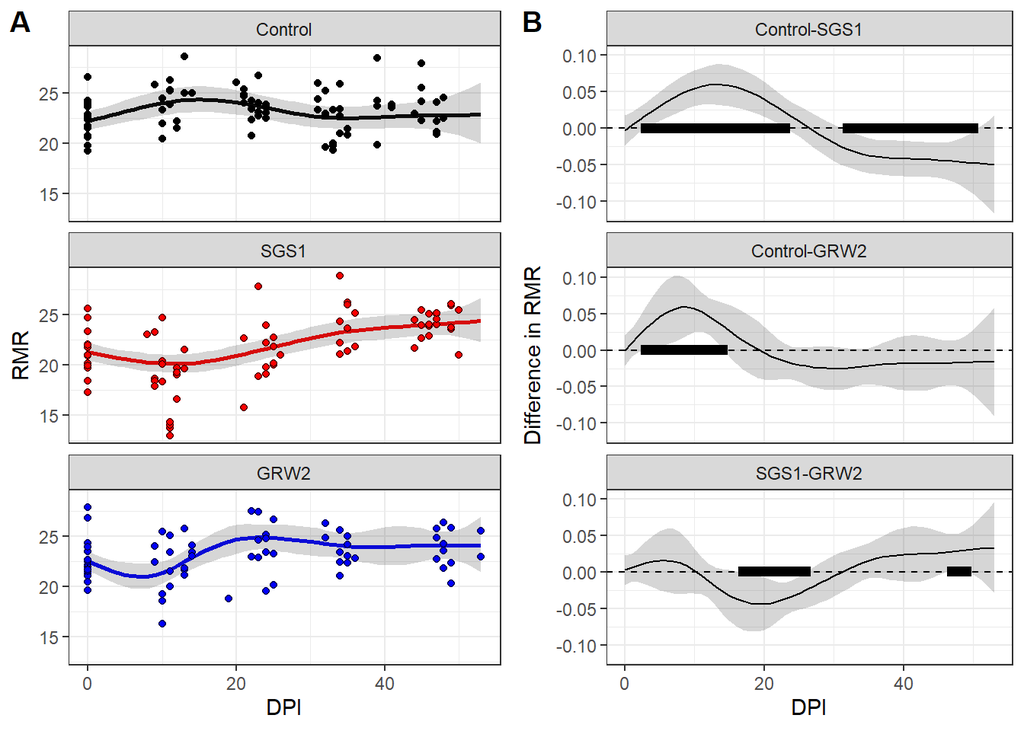

Figure +. RMR at different days after inoculation (DPI) in different birds’ groups. Panel A represents the observed RMR level (dots) and GAM predictions (lines and 95% CI). Panel B represents the difference between smoothers. Time periods when the difference between smoothers is significantly different from zero are marked by black rectangles.

### Второй вариант рисунка

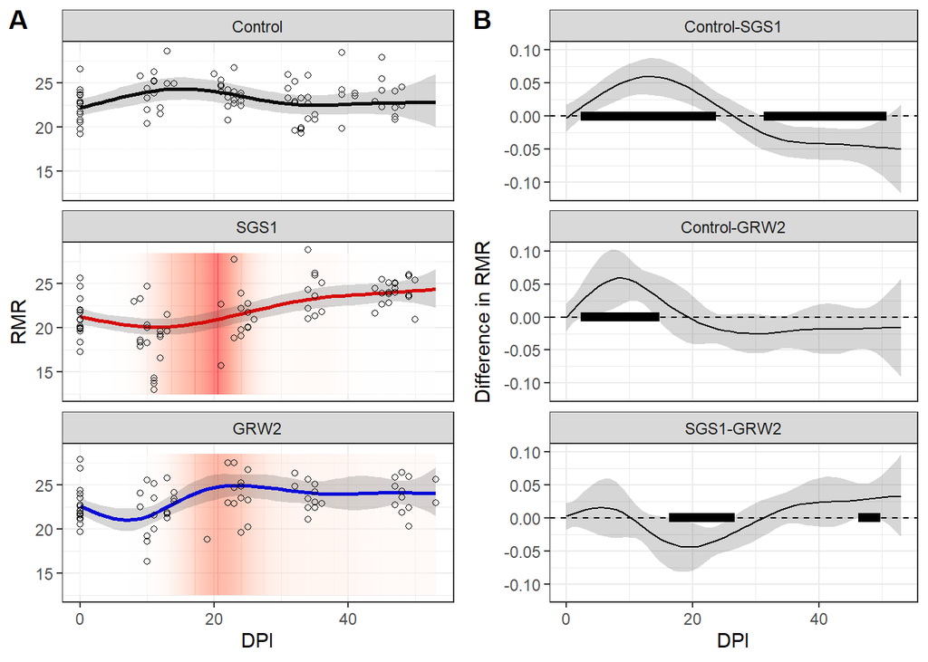

Figure +. RMR at different days after inoculation (DPI) in different birds’ groups. Panel A represents the observed RMR level (dots) and GAM predictions (lines and 95% CI). Panel B represents the difference between smoothers. Time periods when the difference between smoothers is significantly different from zero are marked by black rectangles.  
The red shading reflects the level of parasitemia.

## Динамика интрелейкина

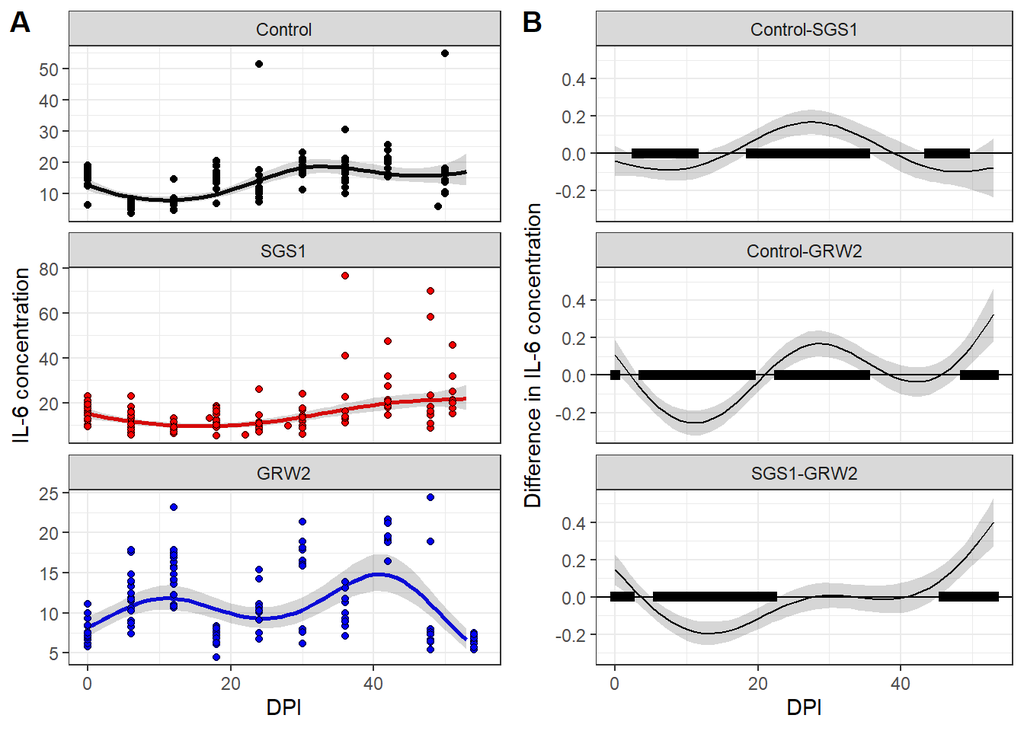

Figure +. IL-6 at different days after inoculation (DPI) in different birds’ groups. Panel A represents the observed IL-6 concentration (dots) and GAM predictions (lines and 95% CI). Panel B represents the difference between smoothers. Time periods when the difference between smoothers is significantly different from zero are marked by black rectangles.

### Второй вариант рисунка

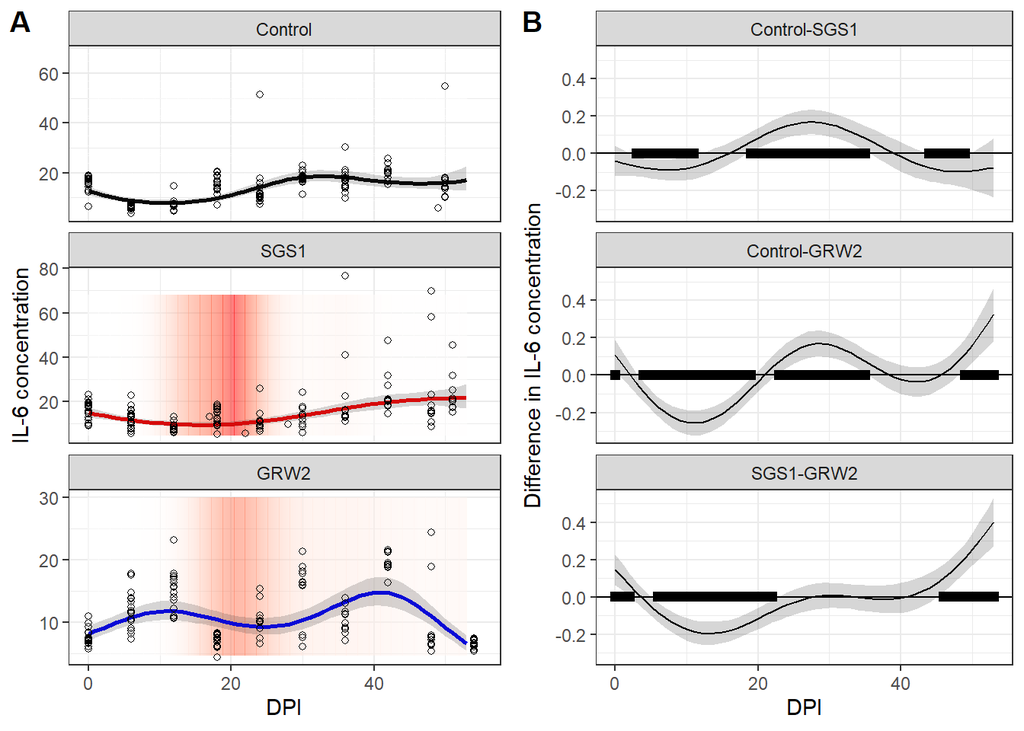

Figure +. IL-6 at different days after inoculation (DPI) in different birds’ groups. Panel A represents the observed IL-6 concentration (dots) and GAM predictions (lines and 95% CI). Panel B represents the difference between smoothers. Time periods when the difference between smoothers is significantly different from zero are marked by black rectangles. The red shading reflects the level of parasitemia.